# LOGM 655 Project Report

As a example, republicans say freedom the most with 190 instances followed by 165 instances of nation. The democrats on the other hand use the words jobs 393 times followed by children 213 times. We can see, based on the word frequency, where the presidents of each party typically guided their speeches.

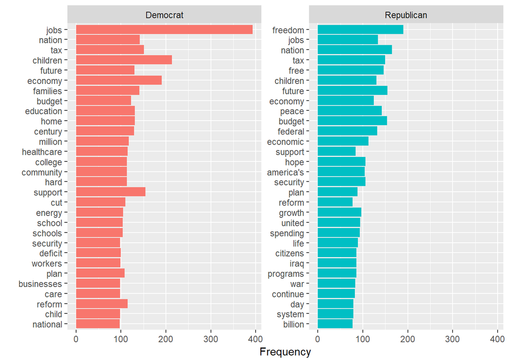

```r
# Next I looked plotted the 30 most common words among each party.  In general, they share a lot of the common words

speech_tidy %>%
  anti_join(new_stop_words) %>%
  group_by(Part) %>%
  count(word, sort = TRUE) %>%
  top_n(30) %>%
  ungroup() %>%
  dplyr::mutate(YearOfSpeech = year[i]) %>%
  mutate(YearOfSpeech = base::factor(YearOfSpeech, levels = year),
         text_order = base::nrow(.):1) %>%
  arrange(desc(word)) %>%
  ## Pipe output directly to ggplot
  ggplot(aes(reorder(word, text_order), n, fill = Part)) +
  geom_bar(stat = "identity") +
  facet_wrap(~ Part, scales = "free_y") +
  labs(x = "", y = "Frequency") +
  coord_flip() +
  theme(legend.position="none")
```

It warranted looking into the most popular words during a entire presidency. Instead of gaining insight about the addresses as a whole or by party, analysis by each president can be very telling about the hot issues at the time as well as what the president thought was important to address at that time.

As discussed previously, both Clinton and Obama were president when we, as a country, were attempting to build or rebuild our economy and grow the amount of jobs. The most popular words in Bush 43’s addresses almost all revolve around the wars in Iraq and Afghanistan by mentioning Iraq, freedom, and terrorists. Reagan and Bush seemed to be the two presidents who blend their messaging between freedom and economy building. They both were concerned with the Cold War but also the economic growth in the 80’s revolving around trickle down economics.

```r
#This next one looks at the top 5 words by president

speech_tidy %>%
  dplyr::anti_join(new_stop_words) %>%
  dplyr::group_by(Pres)%>%
  dplyr::count(word, sort = TRUE)%>%
  dplyr::top_n(5) %>%
  print(n = nrow(.))
```

```
## # A tibble: 28 x 3
## # Groups:   Pres [5]
##    Pres    word           n
##    <chr>   <chr>      <int>
##  1 Obama   jobs         255
##  2 Clinton children     176
##  3 Clinton jobs         138
##  4 Obama   economy      115
##  5 Clinton support      102
##  6 Clinton century       96
##  7 BushW   nation        92
##  8 Clinton welfare       89
##  9 Obama   energy        89
## 10 Reagan  freedom       87
## 11 BushW   iraq          82
```

[output cut: 17 more lines]

Bush 43 talks a little bit about the economy (mainly in his 2001 SOTU before 9/11 occurred) but most of his words involve the military, freedom, and defense topics. As noted previous, Reagan and Bush split their messages between discussing freedom and security in response to the Cold War but also their attempts to grow the US economy in the 80’s.

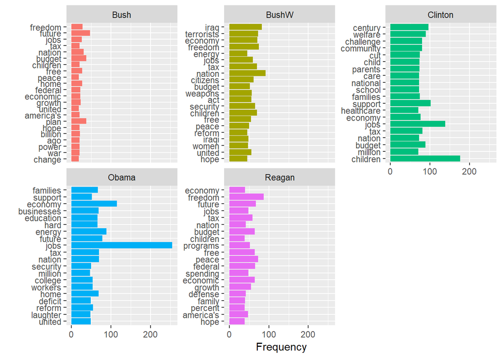

```r
#Finally, this last one is a plot, by president, and their 20 most common words across all of their speeches.

speech_tidy %>%
  anti_join(new_stop_words) %>%
  group_by(Pres) %>%
  count(word, sort = TRUE) %>%
  top_n(20) %>%
  ungroup() %>%
  dplyr::mutate(YearOfSpeech = year[i]) %>%
  mutate(YearOfSpeech = base::factor(YearOfSpeech, levels = year),
         text_order = base::nrow(.):1) %>%
  arrange(desc(word)) %>%
  ## Pipe output directly to ggplot
  ggplot(aes(reorder(word, text_order), n, fill = Pres)) +
  geom_bar(stat = "identity") +
  facet_wrap(~ Pres, scales = "free_y") +
  labs(x = "", y = "Frequency") +
  coord_flip() +
  theme(legend.position="none")
```

## Topic modeling

I next wanted to see what some of the topic model packages could provide based on the SOTU. In some in-class examples, we saw distinct breaks in topics regarding tweets about the US Air Force. The goal was to see if these packages could break the addresses into distinct and independent “categories”. My initial assessment is that, if the packages can do it, it will likely break the topics in the economy and the national security and perhaps one overlap category for additional items.

For both the LSA, LDA, and STM topic models, I ran them with two, three, and four topics to see what results they generated. Similar the multivariate method, factor analysis, there is a human aspect of identifying the number of factors, or topics in this case, that best explain the data. Thus, one has to use a bit of trial and error to see what works out best. In all three of the topic modeling methods, none of them seems to create any great separation between the topics, whether I used two, three, or four topics. Even though I ran each method with two to four topics, for the brevity of this report, I show the bleed over of topics using three topics for each method.

For LSA, there is very poor separation among the topics. The first topic seems to revolve around general SOTU and political areas like the economy and national defense. The second has a blend of national defense, the economy, and social topics like healthcare and education. The third seems to mainly focus on the wars in Iraq and Afghanistan but has some other areas in it at well.

```r
#Create tibble to run LSA

speech_lsa <- tibble:: tibble()

for(i in seq_along(project_sotu)) {

  clean <- tibble::tibble(speech1 = base::seq_along(project_sotu[i]),
                          text = project_sotu[i]) %>%
    dplyr::mutate(Pres = President[i]) %>%
    dplyr::mutate(Part = Party[i])%>%
    # tidytext::unnest_tokens(word, text) %>%
    dplyr::mutate(YearOfSpeech = year[i]) %>%
    dplyr::select(YearOfSpeech, dplyr::everything())

  speech_lsa<- base::rbind(speech_lsa, clean)

}

speech_lsa <- speech_lsa %>%
  select(-speech1)

speech_lsa$YearOfSpeech <- base::factor(speech_lsa$YearOfSpeech, levels = year)
rename(speech_lsa, textwords = text)

#I need to set up my tibble to put it in the form for a term document matrix.

speech_lsa_dfm <- speech_lsa%>%
  unnest_tokens(word,text)%>%
  anti_join(new_stop_words)%>%
  add_count(word, sort = TRUE)


dfm_speech_lsa <- speech_lsa_dfm %>%
  cast_dfm(YearOfSpeech,word,n)

# Set up variable to run LSA.
MyLSA <- lsa(dfm_speech_lsa, dims = 3)

MyLSA$dk <- abs(MyLSA$dk)
```

Below are the three topics generated from LSA.

```r
head(MyLSA$dk[order(-MyLSA$dk[,1]),],10)
```

```
##               [,1]        [,2]       [,3]
## jobs     0.2942823 0.103023798 0.08071915
## children 0.1915348 0.067053440 0.05253637
## nation   0.1714320 0.060015761 0.04702235
## economy  0.1711254 0.002259984 0.07896914
## tax      0.1595144 0.052631144 0.08920385
## future   0.1591470 0.055714957 0.04365267
## budget   0.1541213 0.053955537 0.04227416
## support  0.1329017 0.046526876 0.03645381
## freedom  0.1284344 0.044962948 0.03522847
## families 0.1175402 0.007352435 0.04758068
```

```r
head(MyLSA$dk[order(-MyLSA$dk[,2]),],10)
```

```
##                  [,1]      [,2]       [,3]
## college    0.04384249 0.1957238 0.14762458
## healthcare 0.07901591 0.1695780 0.02831395
## terrorists 0.03907300 0.1621243 0.08003801
## businesses 0.03869125 0.1548170 0.07319671
## iraq       0.03043472 0.1546262 0.18884464
## medicare   0.03710979 0.1388969 0.01797813
## business   0.04742084 0.1236387 0.02714447
## workers    0.07772489 0.1215209 0.07677592
## federal    0.10098164 0.1213244 0.07679294
## spending   0.07656634 0.1195034 0.00683095
```

```r
head(MyLSA$dk[order(-MyLSA$dk[,3]),],10)
```

```
##                   [,1]         [,2]       [,3]
## iraq        0.03043472 0.1546261876 0.18884464
## community   0.06923274 0.0054524758 0.16630910
## century     0.08757027 0.0006883826 0.14944200
## college     0.04384249 0.1957238449 0.14762458
## challenge   0.05730169 0.0153204072 0.14561987
## energy      0.07956520 0.0760989697 0.12874489
## afghanistan 0.01929225 0.0202145005 0.11411634
## al          0.01355432 0.0784046670 0.10047969
## percent     0.08411039 0.0083094798 0.09987324
## pay         0.06776626 0.0422545284 0.09733053
```

Using LDA this time produced similar “blurry”" results to LSA. There is poor separation in the topics. The first deals with the economy and social issues while the second has economy and national defense mostly. The third appears to be a catch all for other words.

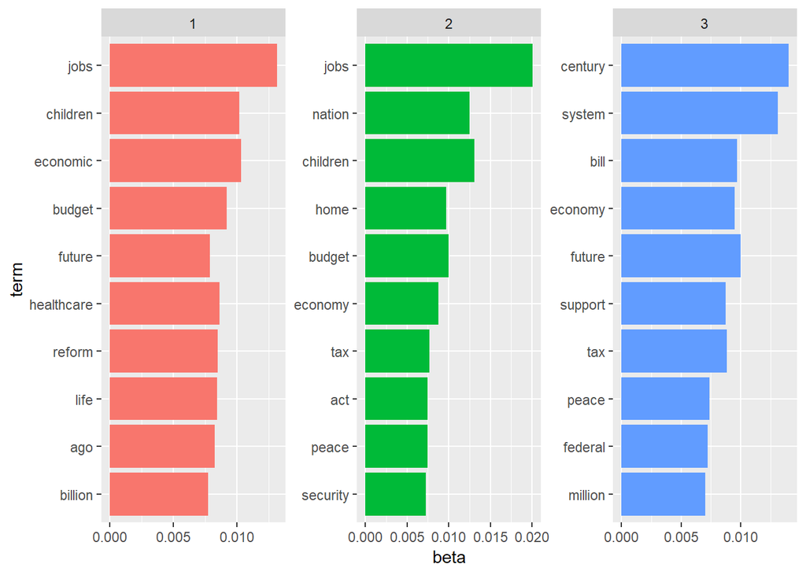

```r
MyLDA <- LDA(dfm_speech_lsa, k = 3, control = list(seed = 1234))

topics_speech_LDA <- tidy(MyLDA, matrix = "beta")


speech_top_terms <- topics_speech_LDA %>%
  group_by(topic) %>%
  top_n(10, beta) %>%
  ungroup() %>%
  arrange(topic, -beta)

speech_top_terms %>%
  mutate(term = reorder(term, beta)) %>%
  ggplot(aes(term, beta, fill = factor(topic))) +
  geom_col(show.legend = FALSE) +
  facet_wrap(~ topic, scales = "free") +
  coord_flip()
```

After running LSA and LDA analysis, I used a different topic modeling package presented in class called Structural Topic Modeling. After LSA and LDA produced mostly indistinguishable results, I imagine STM will do something similar but wanted to check regardless. Like LSA and LDA, I used two, three, and four topics to see which best explained the data. None performed terribly well to split the data, so I stuck with three topics.

```r
#Next I am going to do STM based on the SOTUs.
speech_tidy_model <- tibble:: tibble()

for(i in seq_along(project_sotu)) {

  clean <- tibble::tibble(speech1 = base::seq_along(project_sotu[i]),
                          text = project_sotu[i]) %>%
    dplyr::mutate(Pres = President[i]) %>%
    dplyr::mutate(Part = Party[i])%>%
   # tidytext::unnest_tokens(word, text) %>%
    dplyr::mutate(YearOfSpeech = year[i]) %>%
    dplyr::select(YearOfSpeech, dplyr::everything())

  speech_tidy_model<- base::rbind(speech_tidy_model, clean)


}

#Remove created column called speech1
speech_tidy_model <- speech_tidy_model %>%
  select(-speech1)

speech_tidy_model$YearOfSpeech <- base::factor(speech_tidy_model$YearOfSpeech, levels = year)
rename(speech_tidy_model, textwords = text)

#I need to set up my tibble to put it in the form for a document frequency matrix.

speech_topic_model_Tidy <- speech_tidy_model%>%
                            unnest_tokens(word,text)%>%
                            anti_join(new_stop_words)%>%
                            add_count(word, sort = TRUE)


dfm_speech <- speech_topic_model_Tidy %>%
  cast_dfm(YearOfSpeech,word,n)

#Now using my document frequency matrix, I can plug that into the stm (structual topic model) function in the STM package to create my topic model and look at the individual topics.


topic_model3 <- stm(dfm_speech, K = 3, init.type = "LDA")
```

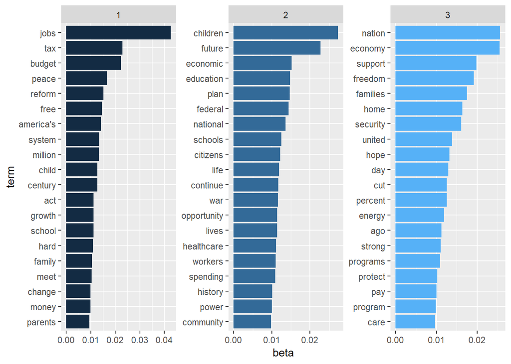

```r
topic_model3 <- tidy(topic_model3)

topic_model3 %>%
  group_by(topic) %>%
  top_n(20) %>%
  ungroup %>%
  mutate(term = reorder(term, beta)) %>%
  ggplot(aes(term, beta, fill = topic)) +
  geom_col(show.legend = FALSE) +
  facet_wrap(~topic, scales = "free") +
  coord_flip()
```

Ultimately, none of the topic modeling methods performed terribly well on the SOTU addresses. My best explanation is that each SOTU address constantly blends discussion about national defense, social issues, and the economy throughout each speech, not to mention combining these major topics in each portion of the speech. For example, Obama may have discussed something like ending the war in Iraq so that money can be shifted towards creating jobs and funding social programs. Sentences like this that combine multiple topics would likely make it hard for a program to find strong separation between topics.

## Sentiment Analysis

Initially, I though sentiment analysis would show which presidents would use more positive language than others and vice versa. However, as I thought about it further and as the analysis will show, presidents very rarely will talk about negative ideas in their addresses. As mentioned before, presidents want to highlight their accomplishments and talk about how their agendas are best, so they are going to use mainly positive words.

Since presidents want to use positive words, I decided to conduct sentiment analysis, by president by speech. For example, the following sentiment analysis shows net positive words used by Clinton in his first through his eighth speech to see the net amount of positive words used as the years passed. This was done for all presidents. My thought was that the net positive sentiments will increase as the length of the presidency increases so the president can boast about his accomplishments while in office.

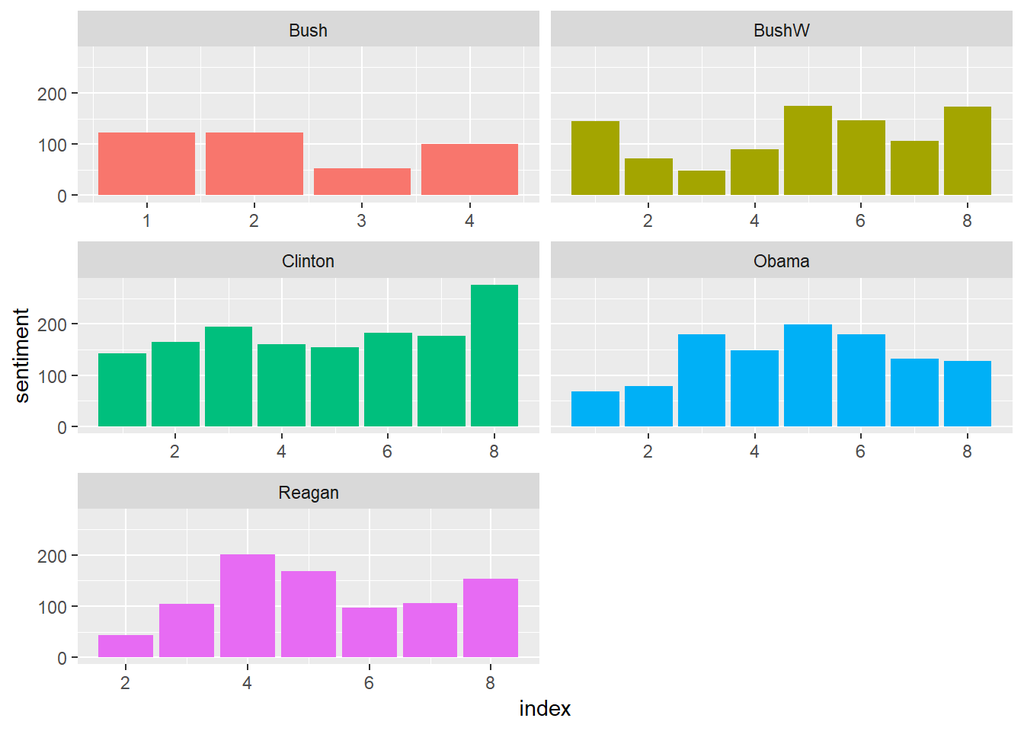

```r
# Set up vector that identifies the which speech it is for the president
numspeech <- c(2,3,4,5,6,7,8,1,2,3,4,1,2,3,4,5,6,7,8,1,2,3,4,5,6,7,8,1,2,3,4,5,6,7,8)

proj_sent <- tibble:: tibble()

for(i in seq_along(project_sotu)) {

  clean <- tibble::tibble(speech1 = base::seq_along(project_sotu[i]),
                          text = project_sotu[i]) %>%
    dplyr::mutate(Pres = President[i]) %>%
    dplyr::mutate(Part = Party[i])%>%
    dplyr::mutate(speechnum = numspeech[i]) %>%
    dplyr::mutate(YearOfSpeech = year[i]) %>%
    tidytext::unnest_tokens(word, text) %>%
    dplyr::select(YearOfSpeech, dplyr::everything())
  proj_sent<- base::rbind(proj_sent, clean)

}

proj_sent <- proj_sent %>%
  select(-speech1)

proj_sent$YearOfSpeech <- base::factor(proj_sent$YearOfSpeech, levels = year)

#This does sentiment analysis by president, by speech number of theirs

proj_sent_plot <- proj_sent %>%
  inner_join(get_sentiments("bing")) %>%
  count(Pres,index = speechnum, sentiment)%>%
  spread(sentiment, n, fill = 0) %>%
  mutate(sentiment = positive - negative)

ggplot(proj_sent_plot, aes(index, sentiment, fill = Pres)) +
  geom_col(show.legend = FALSE) +
  facet_wrap(~Pres, ncol = 2, scales = "free_x")
```

Using sentiment analysis yields a couple interesting results but nothing earth-shattering. My theory that the number of positive words would increase was mostly wrong with the exception of Clinton. One interesting thing is that for Bush 43’s second and third speech, these two occurred after September 11th and around the beginning of the Afghanistan and Iraq wars, thus making sense he had less positive words. Additionally, in the middle of Reagan’s presidency, when he was really pushing his trickle down economics policy, the net amount of positive words increases. Finally, it appears as though Reagan, Bush 43, and Obama all had higher than average net positive words around their 4th and 5th years in office, the addresses leading up to and immediately after reelection.

## Word Cloud

Word clouds, while they typically don’t have a analytic effect, can be useful to visualize data and word frequency. As a final note to this project, I thought it might be worthwhile to try a couple different types of word clouds. The first takes Bush 43’s first SOTU address in 2001 and Obama’s last address in 2016 . These share a lot of the same words among in these speeches, which makes sense as both of them were focusing on the economy at this time. Bush 43 was focusing on the economic decline coming out of the technology bubble burst and Obama was still still dealing with the effects of the housing market collapse in 2008.

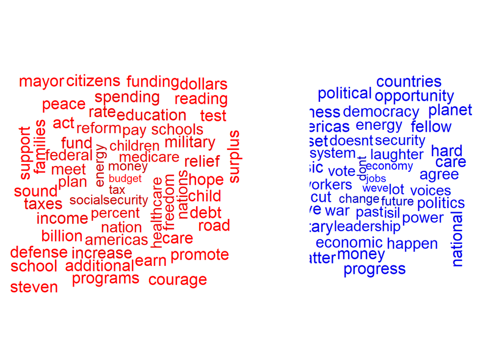

```r
library(wordcloud)
library(tm)
library(xtable)

Bush_Obama <- project_sotu[c(20,35)]
BOyear <- c(2001,2016)
Bush_Obama <- cbind(Bush_Obama,BOyear)
Bush_Obama <- as.data.frame(Bush_Obama)

colnames(Bush_Obama)<- c('speechtext','year')



docsBO <- Corpus(VectorSource(Bush_Obama$speechtext)) %>%
  tm_map(removePunctuation) %>%
  tm_map(removeNumbers) %>%
  tm_map(tolower)  %>%
  tm_map(removeWords, new_stop_words$word) %>%
  tm_map(stripWhitespace) %>%
  tm_map(PlainTextDocument)

tdmBO <- TermDocumentMatrix(docsBO) %>%
  as.matrix()
colnames(tdmBO) <- c("Bush","Obama")


bushsotu <- as.matrix(tdmBO[,1])
bushsotu <- as.matrix(bushsotu[order(bushsotu, decreasing=TRUE),])


obamasotu <- as.matrix(tdmBO[,2])
obamasotu <- as.matrix(obamasotu[order(obamasotu, decreasing=TRUE),])

par(mfrow=c(1,2))
#Create word cloud of Bush speech
wordcloud(rownames(bushsotu), bushsotu, min.freq =5, scale=c(.9, 1.5),
          random.order = FALSE, random.color = FALSE,
          colors= c("red1","red2","red3","red"))

#Create word cloud of Obama speech
wordcloud(rownames(obamasotu), obamasotu, min.freq =5, scale=c(.9, 1.5),
          random.order = FALSE, random.color = FALSE,
          colors= c("blue1","blue2","blue3","blue"))
```

I then created a comparison word cloud to put these two speeches together to look at differences in the key words.

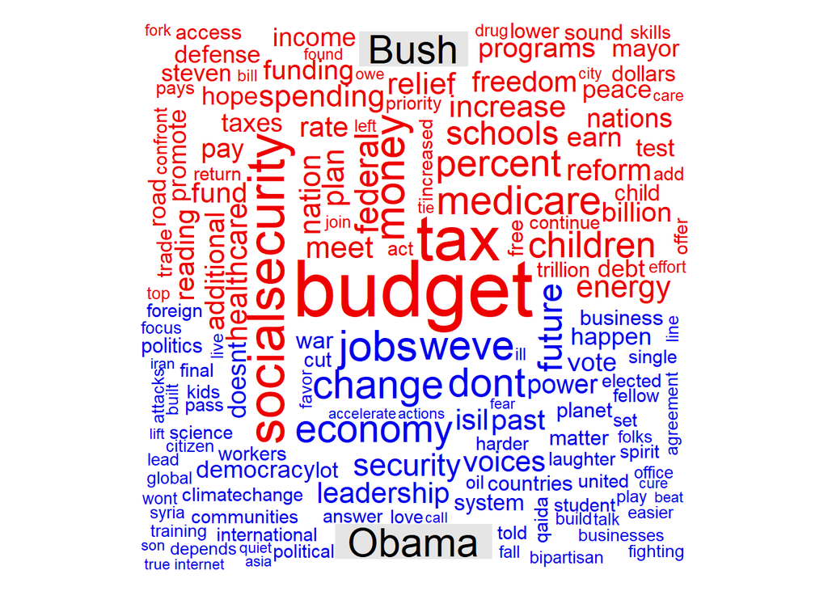

```r
par(mfrow=c(1,1))
comparison.cloud(tdmBO, random.order=FALSE, colors = c("red2","blue2"),
                 title.size=2, max.words=400)
```

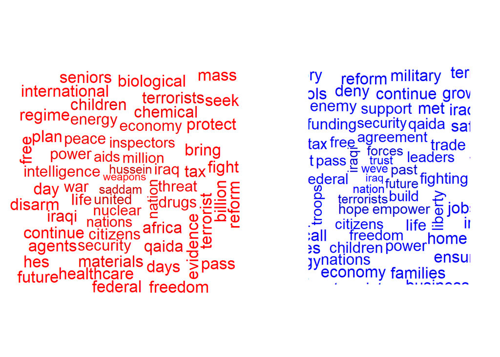

```r
Bush_Obama2 <- project_sotu[c(22,27)]
BOyear <- c(2003,2008)
Bush_Obama2 <- cbind(Bush_Obama2,BOyear)
Bush_Obama2 <- as.data.frame(Bush_Obama2)

colnames(Bush_Obama2)<- c('speechtext','year')



docsBO2 <- Corpus(VectorSource(Bush_Obama2$speechtext)) %>%
  tm_map(removePunctuation) %>%
  tm_map(removeNumbers) %>%
  tm_map(tolower)  %>%
  tm_map(removeWords, new_stop_words$word) %>%
  tm_map(stripWhitespace) %>%
  tm_map(PlainTextDocument)

tdmBO2 <- TermDocumentMatrix(docsBO2) %>%
  as.matrix()
colnames(tdmBO2) <- c("Bush","Obama")

bushsotu2 <- as.matrix(tdmBO2[,1])
bushsotu2 <- as.matrix(bushsotu2[order(bushsotu2, decreasing=TRUE),])

obamasotu2 <- as.matrix(tdmBO2[,2])
obamasotu2 <- as.matrix(obamasotu2[order(obamasotu2, decreasing=TRUE),])


par(mfrow=c(1,2))
#Create word cloud of Bush speech
wordcloud(rownames(bushsotu2), bushsotu2, min.freq =5, scale=c(.9, 1.5),
          random.order = FALSE, random.color = FALSE,
          colors= c("red1","red2","red3","red"))

#Create word cloud of Obama speech
wordcloud(rownames(obamasotu2), obamasotu2, min.freq =5, scale=c(.9, 1.5),
          random.order = FALSE, random.color = FALSE,
          colors= c("blue1","blue2","blue3","blue"))
```

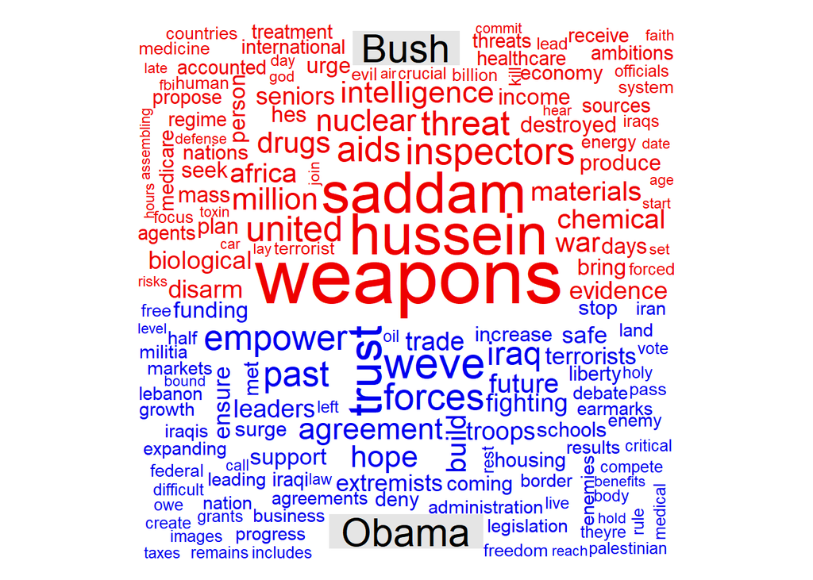

```r
par(mfrow=c(1,1))
comparison.cloud(tdmBO2, random.order=FALSE, colors = c("red2","blue2"),
                 title.size=2, max.words=400)
```

# Findings and Conclusions

The goal of this project was to see what trends and themes exist in 35 of the most recent SOTU addresses by using various text mining techniques instead of reading all 35 documents fully. The initial analysis which used frequency of words and sliced the data in different ways to see what each president and party tended to focus on. Of all of the types of analysis, this proved to be the most interesting and telling. The topic modeling methods provided very little in terms of insight. The sentiment analysis, while enjoyable to perform, yielded a couple interesting points but nothing too important.

One of the goals of this project was to take a sample of speeches, train a model of them, and see if the model was able to predict the president or party based on the validation set of speeches. I was unable to get this to work and finalize this portion of the analysis. Given more time, the next step I would take in this project would be to make the classification model(s) work to see how well they can predict the president of a speech given his other speeches. This may be telling about not only about what a given president says but also the manner in which he says it.